# SQL

올림푸스

2020-04-27

## DB 사용환경

- Oracle XE 11g / Oracle 12c / Oracle ATP의 세가지 DB를 사용하여 원본 CSV 파일을 테이블로 업로드하여 데이터 삽입, 수정, 삭제를 진행했다.
- R 혹은 Python에서 Oracle ATP의 테이블을 접근하여 데이터를 사용할 수 있도록 환경설정하였다.
- 최종적으로, 테이블의 업로드 속도 용량의 제한이 없는 Oracle 11g를 사용하여 계정을 생성하고 테이블을 생성하여 데이터를 수정하였다.
- DB에 접속하는 툴로 Sql Developer를 사용하였다.

### 1. LOTTE 사용자 생성

- 계정 생성 권한을 가지는 SYSDBA 역할을 하는 SYS 계정으로 테이블을 다루는 사용자를 생성한다.

```
SET TERMOUT OFF

SET ECHO OFF


-- 사용자의 권한과 테이블 스페이스를 지정한다.

GRANT CONNECT,RESOURCE,UNLIMITED TABLESPACE TO LOTTE IDENTIFIED BY LOTTE;

ALTER USER LOTTE DEFAULT TABLESPACE USERS;

ALTER USER LOTTE TEMPORARY TABLESPACE TEMP;

CONNECT LOTTE/LOTTE


COMMIT;


SET TERMOUT ON

SET ECHO ON
```

### 2. 데이터 임포트 (csv to table)

- 원본 CSV 파일을 테이블에 담기 위해 Sql developer의 데이터 임포트 기능을 사용했다.

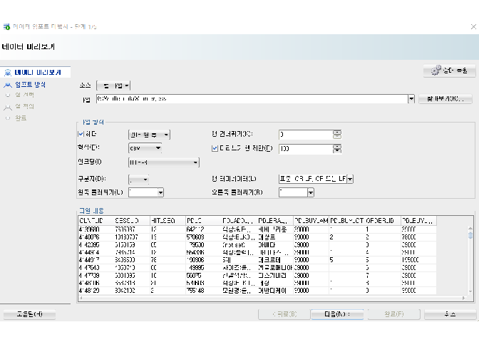

- 인코딩으로는, 한글을 인식하는 UTF-8으로 지정하였다.
- 데이터를 토대로 모델링한 결과, 아래와 같이 릴레이션을 결정하였다.

베이스테이블

1. 고객(클라이언트ID(PK), 성별, 연령대)
2. 상품(상품코드(PK), 상품명, 상품분류코드(FK))
3. 세션(클라이언트ID(FK), 세션ID, 세션일련번호, 세션일자, 총페이지조회건수, 총세션시간값, 기기유형, 지역코드(FK))
4. 검색어(클라이언트ID(FK), 세션ID(FK), 검색키워드명, 검색건수)
5. 검색(클라이언트ID(FK), 세션ID(FK), 검색키워드명(FK))
6. 처리(클라이언트ID(FK), 세션ID(FK), 검색키워드명(FK))
7. 구매(구매번호(PK), 클라이언트ID(FK), 세션ID(FK), 히트일련번호, 상품코드, 상품옵션정보, 상품브랜드, 단일상품금액, 구매건수)
8. 일별검색어(검색일자(PK), 검색키워드명(PK), 검색건수)

코드테이블

1. 상품분류(상품분류코드(PK), 상품 대분류명, 상품 중분류명, 상품 소분류명)
2. 지역(지역코드(PK), 지역대분류, 지역중분류)
- import한 원본 데이터테이블에서 인조키를 추가하거나, 코드 테이블로 분리하기 위하여 테이블을 수정한다.

### 3. 상품 CSV파일 분리

- 상품 CSV 파일은 논리적 모델링 결과, 상품 테이블인 Product 테이블과, 분류를 갖는 Master 코드테이블로 분리한다.
- product_raw 테이블에 상품 CSV파일을 업로드하여 이를 분리한다.

#### 1) MASTER 테이블 분리

```
-- 원본 CSV의 데이터를 담는 테이블 생성

CREATE TABLE product_raw(
    PD_C NUMBER(10,0),
    PD_NM VARCHAR2(400),
    CLAC1_NM VARCHAR2(50),
    CLAC2_NM VARCHAR2(100),
    CLAC3_NM VARCHAR2(100)
);




-- 원본 CSV파일의 상품데이터에서, 분류를 담는 master 코드 테이블을 분리


-- 분류 테이블의 소분류에 따른, 인조키 생성

-- 인조키를 위한 시퀀스 생성

CREATE SEQUENCE master_clac_seq
START WITH 1
INCREMENT BY 1;


-- 분류를 담고 있는 테이블 생성

CREATE TABLE MASTER(
    clac_c NUMBER(3),
    clac1_nm VARCHAR2(50),
    clac2_nm VARCHAR2(100),
    clac3_nm VARCHAR2(100)
);



-- 대/중/소분류를 담고 있는, master2 테이블에서 master테이블에 분류를 담는다

INSERT INTO MASTER(clac1_nm, clac2_nm, clac3_nm)
SELECT clac1_nm, clac2_nm, clac3_nm
FROM  master2
ORDER BY clac1_nm ASC, clac2_nm ASC, clac3_nm ASC;



-- 소분류로 구분가능한 분류번호를 담는 clac_c를 시퀀스를 이용해 업데이트 해준다.

UPDATE MASTER
SET clac_c = master_clac_seq.NEXTVAL;



-- master 테이블의 기본키를 clac_c로 지정한다.

ALTER TABLE MASTER
ADD CONSTRAINT master_clac_pk PRIMARY KEY(clac_c);
```

#### 2) PRODUCT 테이블 분리

- 상품 CSV 테이블에서, 분류 컬럼을 제외한 컬럼을 Product 테이블에 삽입한 후, Master 테이블의 기본키인 각 상품에 해당하는 분류를 컬럼으로 갖는다.
- Product 테이블은 기본키로 상품코드를 갖고, 분류코드인 clac_c를 외래키로 갖는다.

```
-- 원본 CSV에서 필요한 분류정보를 제외한 정보를 갖는 product 테이블 생성

CREATE TABLE product(
    PD_C NUMBER(10,0),
    PD_NM VARCHAR2(400),
    CLAC_C NUMBER(3)
);



-- product 테이블에 master테이블에만 존재하는 clac_c값을 넣어준다.

INSERT INTO product(pd_c, pd_nm,clac_c)
SELECT a.pd_c, a.pd_nm, b.clac_c
FROM product_raw a, master b
WHERE a.clac1_nm = b.clac1_nm
    AND a.clac2_nm = b.clac2_nm
    AND a.clac3_nm = b.clac3_nm;


-- product 테이블에 기본키를 추가해준다.

ALTER TABLE product
ADD CONSTRAINT product_pd_c_pk PRIMARY KEY(pd_c);



-- master의 clac_c를 외래키로 가지므로, 제약조건으로 추가한다.

ALTER TABLE product
ADD CONSTRAINT product_clac_c_fk FOREIGN KEY(clac_c) REFERENCES master(clac_c);
```

### 4. 세션 CSV파일 분리

- 세션 CSV 파일은 논리적 모델링 결과, 세션 정보 테이블인 Session 테이블과, 지역분류를 갖는 Area 코드테이블로 분리한다.
- session_raw 테이블에 세션 CSV파일을 업로드하여 이를 분리한다.

#### 1) AREA 테이블 분리

- 세션 CSV 테이블에서, 지역분류 컬럼을 Area 테이블에 삽입한 후, 각 분류값을 유일하게 구분하는 인조키를 생성한다.
- 인조키의 값은 숫자형으로 1~171의 값을 주기 위하여, 시퀀스를 사용한다.

```
-- 원본 CSV를 위한 테이블 생성

CREATE TABLE session_raw(
    clnt_id VARCHAR2(10),
    sess_id VARCHAR2(12),
    sess_seq NUMBER(4),
    sess_dt DATE,
    tot_pag_view_ct NUMBER(3),
    tot_sess_hr_v NUMBER(10),
    dvc_ctg_nm VARCHAR2(10),
    zon_nm VARCHAR2(20),
    city_nm VARCHAR2(30)
);


-- 원본 CSV파일의 세션데이터에서, 지역정보를 담는 area 코드 테이블을 분리


-- 지역 테이블의 도시를 구분하는, 인조키 area_c 갖는 area 테이블 생성

CREATE TABLE area(
    area_c NUMBER(3),
    zon_nm VARCHAR2(20),
    city_nm VARCHAR2(30)
);


-- area테이블에, import한 CSV의 지역의 (도, 시)정보를 area 테이블에 담음.

INSERT INTO area(zon_nm, city_nm)
SELECT DISTINCT area1_nm, area2_nm
FROM session_raw
ORDER BY area1_nm ASC, area2_nm ASC;


-- 인조키를 위한 시퀀스 생성

CREATE SEQUENCE area_clac_seq
START WITH 1
INCREMENT BY 1;


-- 인조키 area_c에 시퀀스를 이용하여, 지역정보를 구분해주는 값 넣어준다.

UPDATE area
SET area_c = area_clac_seq.NEXTVAL;


-- area테이블의 area_c에 기본키를 지정해준다.

ALTER TABLE area
ADD CONSTRAINT area_area_c_pk PRIMARY KEY(area_c);
```

#### 2) SESSION 테이블 분리

```
-- 세션정보를 담는 테이블 생성

CREATE TABLE lsession(
    clnt_id VARCHAR2(10),
    sess_id VARCHAR2(12),
    sess_seq NUMBER(4),
    sess_dt DATE,
    tot_pag_view_ct NUMBER(3),
    tot_sess_hr_v NUMBER(10),
    dvc_ctg_nm VARCHAR2(10),
    area_c NUMBER(3)
);



-- lsession 테이블에 session_raw테이블과 area테이블에서, 구매세션 정보와 지역코드를 삽입한다.

INSERT INTO lsession(clnt_id, sess_id, sess_seq, sess_dt, tot_pag_view_ct, tot_sess_hr_v, dvc_ctg_nm, area_c)
SELECT a.clit_id, a.sess_id, a.sess_seq, a.sess_dt, a.tot_pag_view_ct, a.tot_sess_hr_v, a.dvc_ctg_nm, b.area_c
FROM session_raw a, area b
WHERE a.area1_nm = b.zon_nm
    AND a.area2_nm = b.city_nm;



-- lsession 테이블에 기본키를 추가해준다.

ALTER TABLE lsession
ADD CONSTRAINT lsession_cs_pk PRIMARY KEY(clnt_id, sess_id);


-- area의 area_c를 외래키로 가지므로, 제약조건으로 추가한다.

ALTER TABLE lsession
ADD CONSTRAINT lsession_area_c_fk FOREIGN KEY(area_c) REFERENCES master(area_c);
```

### 5. 주문 CSV파일

- 주문 CSV 파일은 모든 행을 유일하게 구분하기 위해서는, 기본키로 지정해야 하는 컬럼이 5개로 너무 많은 컬럼을 요구한다.
- 따라서, 기본키로 복합키를 지정하지 않고 주문번호를 갖는 인조키인 order_id 컬럼을 생성하여 시퀀스를 사용하여 숫자값을 부여한다.

```
-- CSV 파일을 담는 lorder 테이블 생성

CREATE TABLE lorder(
    clnt_id NUMBER,
    sess_id NUMBER,
    hit_seq NUMBER(3),
    pd_c  NUMBER,
    pd_add_nm VARCHAR2(500),
    pd_bra_nm VARCHAR2(500),
    pd_buy_am NUMBER,
    pd_buy_ct NUMBER
);



-- 기존 변수만으로 기본키를 설정하려면, 5개의 컬럼을 갖는 복합키가 되므로
-- 인조키를 생성하여 lorder 테이블의 행을 구분해준다.

ALTER TABLE lorder
ADD order_id NUMBER;


-- 인조키를 위한 시퀀스 생성

CREATE SEQUENCE order_id_seq
START WITH 1
INCREMENT BY 1;


-- 인조키 order_id에 시퀀스를 이용하여, 인조키를 생성한다.

UPDATE lorder
SET order_id = order_id_seq.NEXTVAL;


-- lorder 테이블에 기본키를 추가한다.

ALTER TABLE lorder
ADD CONSTRAINT lorder_id_pk PRIMARY KEY(order_id);


-- 주문 당 총금액을 컬럼으로 추가한다.

ALTER TABLE lorder
ADD pd_buy_tot NUMBER;


-- 주문 당 총액값을 업데이트한다.

UPDATE lorder
SET pd_buy_tot = pd_buy_am * pd_buy_ct;
```